# Section 301 ‘structural excess capacity’ tariffs: what they entail and what they mean for the UK

Policy analysis, scenarios and general-equilibrium counterfactuals, 25 November 2026 (revised version)

Author

Oleksandr Shepotylo

Published

November 25, 2026

# Key findings

# 1 What the new policy entails

## 1.1 Legal route and timetable

USTR opened sixteen Section 301 investigations on 11 March 2026, three weeks after the Supreme Court ruled that IEEPA does not authorise tariffs. The process drew more than 1,070 written comments, and hearings on 5–8 May 2026 heard nearly 140 witnesses. On 25 November 2026 USTR published 14 determinations (all *unreasonable and burdening U.S. commerce*) and 14 proposed actions as pre-publication Federal Register notices (FRNs).

| Item | Detail |
| --- | --- |
| Comments and requests to appear | due **5 January 2027** (requests to appear: USTR-2026-0741; comments: one docket per economy, e.g. China USTR-2026-0278, EU USTR-2026-0730) |
| Public hearings | from **25 January 2027**, USITC |
| Effective date | not proposed; realistically Q1–Q2 2027 |
| Sunset | EU only: **1 December 2028**, aligned with Regulation (EU) 2026/1455 (EU concessions on US goods, 1 Jul 2026 – 31 Dec 2029) |
| Pending | **Mexico** and **Norway**: no determination “at this time” |
| Multilateral element | comments invited on a **plurilateral agreement on structural excess capacity**, including with China |

The diagnosis is broad. It covers subsidies and state-owned enterprises, but also financial repression, household investment promotion (Japan), “savings promotion that suppresses domestic consumption” (Singapore), currency (Switzerland), past purchases of sanctioned Russian feedstock (Taiwan), and for every economy a “failure to address global excess capacity”. The remedy, however, is a tariff on *all goods*, not on the sectors named.

## 1.2 How it stacks on the regime in force

**The forced-labour Section 301 (FL).** The final action took effect on 24 July 2026 (Presidential memorandum, 91 FR 47717; USTR notice with Annex II, 91 FR 47318). It covers 60 economies:

- **flat 10%:** Argentina, Bangladesh, Cambodia, Canada, Ecuador, El Salvador, Guatemala, Honduras, India, Indonesia, Jordan, Malaysia, Mexico, Pakistan, Sri Lanka, **the United Kingdom**, and Trinidad and Tobago;
- **net of MFN, capped at 10% all-in:** EU and Taiwan;
- **net of MFN, capped at 12.5% all-in:** Japan, Korea and Switzerland;
- **flat 12.5%:** all other covered economies, including China, Vietnam, Thailand and Singapore.

The FL action has a common exemption annex (Part A) and country lists. The UK’s own list (Part B) has 57 lines, including whisky and other spirits, medical instruments and cork. The notice also provides for textile tariff-rate quotas for Bangladesh, Cambodia, Indonesia and Malaysia.

Because the new rates are *net of existing Section 301 duties*, the new duty only **tops up** the FL duty to the headline rate. For China it tops up the FL duty only: the 2018–19 Section 301 duties (25% on Lists 1–3, 7.5% on List 4A, more on the 2024 review lines) stay on top. The table shows what this means for the average tariff each economy pays on *all* its goods: today’s trade-weighted level plus the model’s trade-weighted increment in each scenario.

Table 1: Average US tariff on all goods by exporter, trade-weighted, %. Today: GTA US Tariff Estimates for 25 Nov 2026 (MFN, Section 232, every Section 301 action including China’s 2018 lists, Section 338 and deal terms; 2024 import weights). Scenarios: today plus the incremental excess-capacity duty from the model (2025 weights).

| Economy | US imports 2025 ($bn) | Today | S1 Proposal | S2 Deals signed | S3 Talks fail | Gap to UK under S1 (pp) |
| --- | --- | --- | --- | --- | --- | --- |
| United Kingdom | 54.8 | 7.3 | 7.3 | 7.3 | 7.3 | 0.0 |
| EU | 586.8 | 9.1 | 10.7 | 10.7 | 12.2 | 3.3 |
| Japan | 140.2 | 13.0 | 13.7 | 13.7 | 15.2 | 6.4 |
| Korea | 121.7 | 13.0 | 13.5 | 13.5 | 15.6 | 6.2 |
| Switzerland | 41.7 | 5.3 | 6.3 | 6.3 | 8.2 | -1.1 |
| Taiwan | 198.4 | 5.3 | 5.8 | 5.8 | 7.0 | -1.6 |
| China | 292.5 | 25.0 | 34.7 | 34.7 | 58.8 | 27.4 |
| Vietnam | 191.7 | 13.4 | 22.6 | 16.5 | 22.6 | 15.3 |
| India | 101.4 | 18.2 | 23.8 | 20.8 | 23.8 | 16.5 |
| Thailand | 90.3 | 11.8 | 13.3 | 13.3 | 15.2 | 6.0 |
| Malaysia | 57.2 | 6.3 | 8.7 | 8.7 | 10.8 | 1.4 |
| Indonesia | 34.4 | 14.8 | 20.2 | 20.2 | 24.9 | 12.9 |
| Cambodia | 15.1 | 20.6 | 27.5 | 27.5 | 33.4 | 20.1 |
| Bangladesh | 9.3 | 25.2 | 33.2 | 33.2 | 35.2 | 25.9 |
| Singapore | 31.4 | 19.6 | 22.2 | 19.6 | 22.2 | 14.9 |
| All model economies | 3060.0 | 11.2 | 13.5 | 13.0 | 16.5 | 6.1 |

Averaged over all goods, the margins are much smaller than the headline rates suggest. Exempt goods (aircraft, most pharmaceuticals, smartphones and computers, energy) and Section 232 goods pull every average down. Under the proposal the UK’s average stays at 7.3%, while:

- the EU’s rises from 9.1% to 10.7% (3.3pp above the UK);
- Japan’s rises from 13.0% to 13.7%, and Korea’s from 13.0% to 13.5%;
- China’s rises from 25.0% to 34.7%, and to 58.8% if talks fail;
- India’s rises from 18.2% to 23.8%, and Vietnam’s from 13.4% to 22.6%.

Switzerland and Taiwan stay below the UK on average even under the proposal, mainly because much of what they ship is exempt.

**On covered goods the margins are larger.** Take a covered good with a 2% MFN rate:

- From the UK it pays 12% today and from the EU 10%. Under the proposal the EU pays 15%, so the UK moves from paying 2pp more than EU exporters to paying 3pp less.
- From China the same good pays 14.5% today if it is outside the 2018 Section 301 lists, 22.0% if it is on List 4A and 39.5% if it is on Lists 1–3. The proposal adds 7.5pp to each.

**A second source.** The Yale Budget Lab’s open-source Tariff Rate Tracker (statutory rates at HTS-10) gives almost the same levels today: 10.7% on all model economies, against 11.2% from GTA. The UK is at 7.0%; Germany, France, Italy, the Netherlands and Spain are within 1.6pp; and China is at 25.1%. The exception is pharmaceutical exporters, because the two sources treat generic medicines under the pharmaceutical Section 232 differently. India is at 12.3% in Yale against 18.2% in GTA, Singapore 25.6% against 19.6%, and Ireland 2.3% against 4.6%.

Many UK exports to the US are touched by neither action. Some are exempt (aircraft engines and parts, pharmaceuticals, spirits). Others sit under Section 232 (cars, steel, aluminium).

## 1.3 Exemptions

- **The common annex is verified.** The new core annex of 2,114 HTS-8 lines is *identical* to the FL Annex II Part A (2,113 lines, the same 541 civil-aircraft and 700 pharma-use tags), plus agglomerated iron ore (2601.12.00). Each economy’s extra lines largely mirror its FL country list (the EU: 33 of 44 lines identical; Switzerland 123 of 124; Cambodia 138 of 139).
- **The Section 232 carve-out** comes from the official lists:
  - metals annexes I-A, I-B and III of Proclamation 11021 (April 2026; Annex II “removed from scope” lines excluded);
  - autos and parts (Proclamation 10908);
  - medium and heavy vehicles, parts and buses (Proclamation 10984);
  - timber, upholstered furniture and cabinets (Proclamation 10976).

  The semiconductor Section 232 (Proclamation 11002) is narrow: advanced AI chips in 8471.50, 8471.80 and 8473.30 only. Outside chapters 72–76, metal-derivative lines count only where metal makes up at least 15% of the article’s weight. Taken together, the carve-out covers 28% of the targets’ 2025 US imports. **China gets no Section 232 carve-out.**
- **China’s tiers.** Annex A (= the common annex) pays 10%; Annex B (77 lines from the “30-for-30” list: toys, fireworks, tableware, linens) is exempt; all other goods pay 20% net of FL.

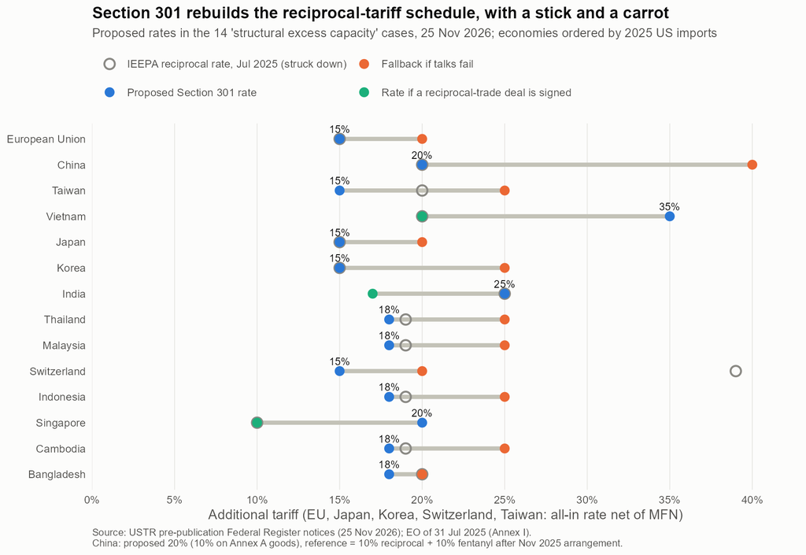

Proposed rates against the struck-down IEEPA rates

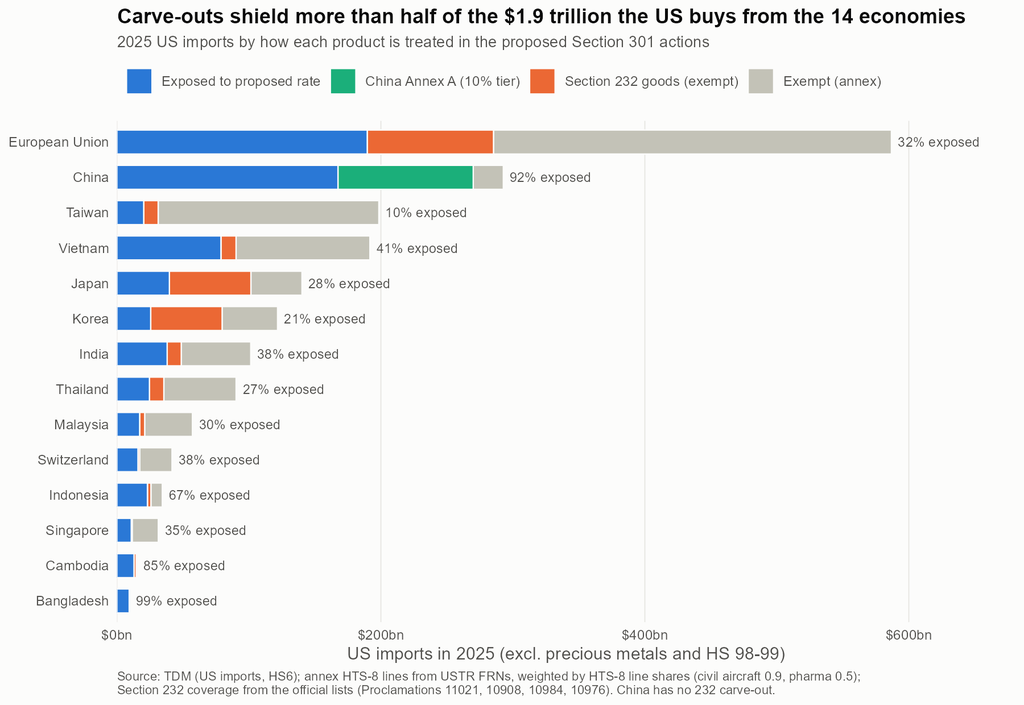

US imports exposed to the proposed tariffs, 2025

## 1.4 Effective incremental tariffs by economy

Each exporter’s incremental tariff is built bottom-up from 2025 US imports at HS6 (TDM):

- **annex exemption:** listed lines as a share of the HTS-8 lines in each HS6 (TRAINS), with civil-aircraft lines weighted 0.9 and pharma-use lines 0.5;
- **Section 232:** the coverage share from the official lists;
- **MFN rates:** US MFN by HS6 (TRAINS);
- **FL tiers:** from the official notice.

The table compares these increments with today’s regime and the last IEEPA day. Both of those are GTA trade-weighted changes since 20 January 2025, so they are like for like.

Table 2: Additional US tariff by exporter, pp, trade-weighted: the last IEEPA day and today’s regime (vs 20 Jan 2025, GTA), and the incremental excess-capacity duty by scenario (2025 weights)

| Exporter | US imports 2025 ($bn) | Last IEEPA day | Today (S0) | S1 Proposal | S2 Deals | S3 Talks fail | S5 UK 15% | S5b UK 20% |
| --- | --- | --- | --- | --- | --- | --- | --- | --- |
| China | 292.5 | 19.9 | 11.8 | 9.7 | 9.7 | 33.8 | 9.7 | 9.7 |
| Vietnam | 191.7 | 15.1 | 9.5 | 9.3 | 3.1 | 9.3 | 9.3 | 9.3 |
| Bangladesh | 9.3 | 20.0 | 10.1 | 8.0 | 8.0 | 9.9 | 8.0 | 8.0 |
| Cambodia | 15.1 | 19.8 | 11.1 | 6.8 | 6.8 | 12.8 | 6.8 | 6.8 |
| India | 101.4 | 17.4 | 15.7 | 5.6 | 2.6 | 5.6 | 5.6 | 5.6 |
| Indonesia | 34.4 | 17.7 | 9.2 | 5.4 | 5.4 | 10.1 | 5.4 | 5.4 |
| Singapore | 31.4 | 3.0 | 19.3 | 2.6 | 0.0 | 2.6 | 2.6 | 2.6 |
| Italy | 68.5 | 10.7 | 9.2 | 2.4 | 2.4 | 5.0 | 2.4 | 2.4 |
| Malaysia | 57.2 | 10.7 | 5.7 | 2.4 | 2.4 | 4.5 | 2.4 | 2.4 |
| France | 62.0 | 9.5 | 6.5 | 2.0 | 2.0 | 4.1 | 2.0 | 2.0 |
| Germany | 142.6 | 11.8 | 10.0 | 1.6 | 1.6 | 3.3 | 1.6 | 1.6 |
| Thailand | 90.3 | 14.9 | 10.1 | 1.5 | 1.5 | 3.4 | 1.5 | 1.5 |
| Switzerland | 41.7 | 4.5 | 4.6 | 0.9 | 0.9 | 2.8 | 0.9 | 0.9 |
| Ireland | 127.1 | 2.5 | 3.9 | 0.8 | 0.8 | 1.5 | 0.8 | 0.8 |
| Japan | 140.2 | 13.2 | 11.5 | 0.7 | 0.7 | 2.1 | 0.7 | 0.7 |
| Korea | 121.7 | 13.9 | 12.8 | 0.5 | 0.5 | 2.6 | 0.5 | 0.5 |
| Taiwan | 198.4 | 7.9 | 4.3 | 0.5 | 0.5 | 1.8 | 0.5 | 0.5 |
| Canada | 350.2 | 6.9 | 8.5 | 0.0 | 0.0 | 0.0 | 0.0 | 0.0 |
| United Kingdom | 54.8 | 6.5 | 6.3 | 0.0 | 0.0 | 0.0 | 1.4 | 2.7 |
| Mexico | 513.1 | 7.4 | 6.2 | 0.0 | 0.0 | 0.0 | 0.0 | 0.0 |

On all US imports, the proposal adds 2.27pp on average. That would be 1.77pp if the three outstanding deals are signed and 5.24pp if talks fail.

Today’s regime is *below* the last IEEPA day for most economies: the UK, the EU, Japan, China, Vietnam and the ASEAN partners. The exceptions include Singapore, which since September 2026 has paid the pharmaceutical Section 232 with no deal ceiling, and Canada. The new action restores much of the gap.

## 1.5 Tariffs on US goods since 2025

| Importer | Change on US goods vs 2022 (trade-weighted) | Basis (GTA records) |
| --- | --- | --- |
| China | +10.1% | 10% on all US goods (a further 24pp suspended until 10 Jan 2027); February 2025 tariffs on coal and LNG (15%) and on crude oil, farm machinery, large cars and pick-ups (10%) |
| EU27 | −1.1% | Regulation 2026/1455: zero duties on US industrial goods (approximated as ch. 25–97) and lobster, from 1 Jul 2026 |
| Canada | +2.9% | 25% on US steel and aluminium; from 8 Sep 2026, counter-tariffs on C$27.6bn of US goods (at about 30%) |

These enter every scenario, and the IEEPA-day versions enter the reference run. In the escalation scenario China adds a mirror tariff, and the EU suspends its concessions and mirrors the US increase.

## 1.6 Recent developments

Table 3: US goods imports by origin, January–May, US$ bn and share (%)

| Origin | 2024 $bn | 2025 $bn | 2026 $bn | 2024 % | 2025 % | 2026 % |
| --- | --- | --- | --- | --- | --- | --- |
| Other targets (12) | 346.8 | 467.1 | 520.5 | 26.7 | 31.1 | 36.4 |
| Mexico & Norway (pending) | 208.3 | 222.3 | 245.1 | 16.0 | 14.8 | 17.2 |
| EU27 | 246.3 | 303.2 | 222.7 | 18.9 | 20.2 | 15.6 |
| Canada | 170.4 | 167.8 | 163.0 | 13.1 | 11.2 | 11.4 |
| Rest of world | 136.3 | 162.2 | 146.1 | 10.5 | 10.8 | 10.2 |
| China | 164.2 | 148.7 | 104.2 | 12.6 | 9.9 | 7.3 |
| United Kingdom | 27.6 | 28.3 | 27.1 | 2.1 | 1.9 | 1.9 |

China’s share of US imports fell from 12.6% to 7.3% between January–May 2024 and January–May 2026. Over the same period the other twelve targets rose from 26.7% to 36.4%, the relocation pattern that the “failure to address excess capacity” findings target. UK exports to the US, net of precious metals, have stayed at about $5–6bn a month.

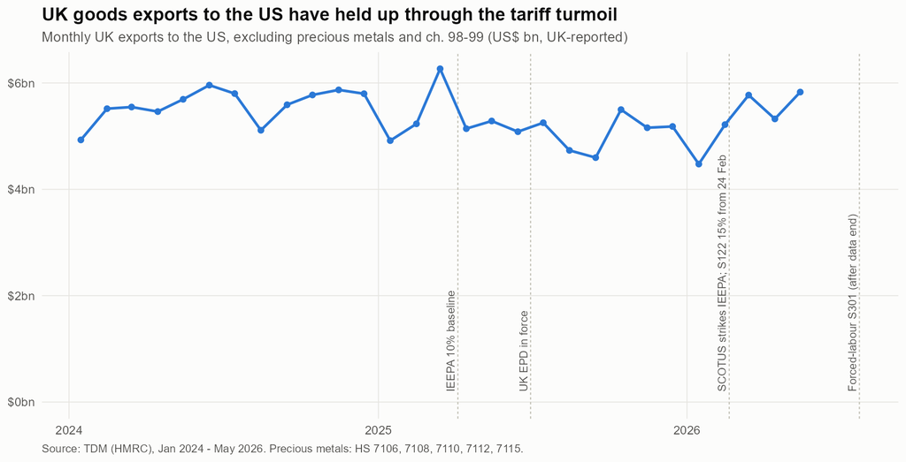

# 2 Scenarios

All scenarios are measured against **S0, the regime in force on 25 November 2026**. S0 contains:

- **US tariffs:** GTA trade-weighted changes since January 2025, covering Section 232, the forced-labour 301 and China’s 2018 301;
- **tariffs on US goods:** China’s, the EU’s and Canada’s changes since 2025.

|  | Scenario | Rates | What it represents |
| --- | --- | --- | --- |
| S1 | **Proposal as published** | headline “up to” rates | USTR adopts the proposals |
| S2 | **Deals signed** | as S1, but India 17, Vietnam 20, Singapore 10 | the carrot works |
| S3 | **Talks fail** | fallback rates for deal partners (EU, Japan, Switzerland 20 all-in; Korea 25 all-in; Taiwan and ASEAN 25; Bangladesh 20; China 40 on all goods); India, Vietnam and Singapore at headline | the stick is used |
| S4 | **Escalation** | S3 + China mirror retaliation + the EU suspends its 2026 concessions and mirrors | retaliation |
| S5 | **UK drawn in at 15%** | S1 + UK at 15% net of existing 301 (core annex + UK FL list, Section 232 carve-out) | the UK is added, as Mexico and Norway may be |
| S5b | **UK drawn in at 20%** | as S5 at 20% | a fallback-type UK rate |
| R0 | *Reference: last IEEPA day* | GTA rates on 19 Feb 2026 | how far today is from the IEEPA world |

# 3 Methodology

**The GE model.**

- *Engine:* `ge_gravity2`, a universal-gravity model (Allen, Arkolakis and Takahashi 2020), using the R port validated in *2026 UK–EU* (18 of 18 tests).
- *Baseline (rebased to 2025):* 81 economies, with bilateral goods trade from TDM for 2025, excluding precious metals and ch. 98–99. Flows are importer-reported where available and exporter-reported otherwise. Gross output is the OECD ICIO 2022 value scaled by World Bank 2022→2025 nominal GDP growth.
  - The baseline checks pass: the zero-shock run reproduces it exactly.
  - China is 9.3% of US imports in the 2025 baseline, against 18.5% in 2022.
- *Elasticities:* θ = 5.14; ψ = 1.99 (central) and 1.01; ψ = 0 (Armington) in the tables.
- *Closure:* trade deficits are held constant in levels, and tariff revenue is a lump sum added after solving.
- *Closure sensitivity:*
  - multiplicative (expenditure proportional to output);
  - revenue spent inside the equilibrium (`ge_tariff_rev.R`, validated against `ge_gravity2` to 1.5e-8 when there are no tariffs).
- *Money values:* £ figures apply the % changes to ONS 2025 GDP and to UK exports to the US in 2025 (UK-reported, excluding precious metals).

**Product layer.** A CES share model within each HS6:

- exporter prices move by (1 + t₀ + Δτ)/(1 + t₀), with t₀ today’s GTA tariff level;
- US spending per product is fixed, with an upper-tier variant at η = 1.5;
- deflection: displaced US sales are redistributed in proportion to each source’s 2025 non-US sales (TDM mirror data), separately for the UK and the EU.

**Uncertainty.** A Monte Carlo of 5,000 draws ran on TAURUS (Aston HPC) in under two minutes on 32 cores. Each draw rebuilds the product-level tariffs with the same code as the central run, and draw 0 reproduces the central run to 1e-13. The draws vary:

- θ ~ U[3.5, 8] and ψ ~ U[1.01, 1.99];
- civil-aircraft share ~ U[0.8, 1] and pharma-use share ~ U[0.3, 0.7];
- the HS6 exemption mapping;
- the final rate as a share of the “up to” ceiling, U[0.75, 1];
- the level of today’s regime, ±20%;
- Section 232 derivative coverage, U[0.5, 1];
- 2025 or January–May 2026 weights.

| Data | Source |
| --- | --- |
| Proposed actions, annexes | 14 USTR pre-publication FRNs, 25 Nov 2026 |
| Forced-labour 301 tiers and Annex II | Presidential memorandum, 91 FR 47717; USTR notice of actions (23 Jul 2026), 91 FR 47318 |
| Section 232 product scope | Proclamations 11021 (annexes), 10908, 10984, 10976, 11002 |
| Trade (HS6, bilateral, monthly to May 2026) | TDM, local database |
| MFN (US, EU, China, Canada) | WITS TRAINS 2022, local |
| US tariffs today, on the last IEEPA day, at the 2025 start | GTA US Tariff Estimates (modelled; 74 of 80 economies queried directly) |
| US tariff levels, second source | Yale Budget Lab Tariff Rate Tracker (statutory, HTS-10; rates in force from 10 Nov 2026, tracker commit a5ddf68, via the halstar79/tariff-rates-build rebuild) |
| Tariffs on US goods | GTA intervention records 142993, 145038, 150376 (China); 148857, 148859 (EU); 148784, 159087 (Canada) |
| GE baseline | TDM 2025 flows; OECD ICIO 2022 output; World Bank WDI GDP 2022 and 2025 |
| Money values | ONS YBHA 2025; FRED DEXUSUK 2025 (1.3192) |

# 4 Results

## 4.1 Global effects

Table 4: Real income (incl. tariff revenue), change vs today’s regime, %, ψ = 1.99, 2025 baseline (central calibration)

| Economy | S1 Proposal | S2 Deals | S3 Talks fail | S4 Escalation | S5 UK 15% | S5b UK 20% | R0 last IEEPA day |
| --- | --- | --- | --- | --- | --- | --- | --- |
| KHM | -1.596 | -1.692 | -2.588 | -2.770 | -1.595 | -1.594 | -2.061 |
| VNM | -0.826 | -0.234 | -0.699 | -0.750 | -0.826 | -0.825 | -0.473 |
| MYS | -0.137 | -0.142 | -0.240 | -0.249 | -0.137 | -0.136 | -0.302 |
| IDN | -0.067 | -0.066 | -0.113 | -0.111 | -0.067 | -0.067 | -0.103 |
| USA | -0.060 | -0.048 | -0.129 | -0.196 | -0.061 | -0.062 | -0.052 |
| CHN | -0.047 | -0.045 | -0.103 | -0.129 | -0.048 | -0.048 | -0.038 |
| BGD | -0.045 | -0.056 | -0.032 | -0.035 | -0.046 | -0.046 | -0.058 |
| IND | -0.030 | -0.008 | -0.011 | -0.020 | -0.030 | -0.030 | 0.004 |
| SGP | -0.027 | 0.006 | -0.007 | -0.012 | -0.027 | -0.027 | 0.413 |
| World | -0.026 | -0.021 | -0.051 | -0.083 | -0.026 | -0.027 | -0.026 |
| KOR | -0.019 | -0.014 | -0.070 | -0.069 | -0.019 | -0.019 | -0.034 |
| ITA | -0.018 | -0.021 | -0.039 | -0.062 | -0.019 | -0.019 | -0.012 |
| THA | -0.014 | -0.033 | -0.060 | -0.107 | -0.013 | -0.012 | -0.253 |
| FRA | -0.013 | -0.015 | -0.027 | -0.053 | -0.013 | -0.013 | -0.030 |
| DEU | -0.010 | -0.014 | -0.023 | -0.047 | -0.010 | -0.010 | -0.017 |
| EU27 | -0.004 | -0.009 | -0.012 | -0.041 | -0.004 | -0.004 | 0.006 |
| JPN | 0.000 | -0.002 | -0.013 | -0.018 | 0.000 | 0.000 | -0.020 |
| CHE | 0.004 | -0.001 | -0.019 | -0.036 | 0.004 | 0.005 | 0.023 |
| IRL | 0.013 | -0.012 | 0.012 | -0.090 | 0.016 | 0.019 | 0.315 |
| TWN | 0.015 | -0.004 | -0.140 | -0.205 | 0.018 | 0.021 | -0.656 |
| GBR | 0.016 | 0.012 | 0.030 | 0.018 | 0.002 | -0.010 | 0.013 |
| CAN | 0.061 | 0.046 | 0.115 | 0.083 | 0.062 | 0.062 | 0.281 |
| MEX | 0.201 | 0.157 | 0.382 | 0.280 | 0.203 | 0.205 | -0.057 |

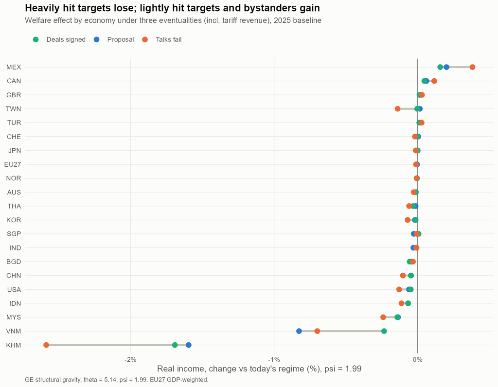

- **Heavily hit targets lose most:** Cambodia (-1.60%), Vietnam (-0.83%), Malaysia (-0.14%) and China (-0.05%).
  - When the three outstanding deals are signed, Vietnam’s loss shrinks to -0.23%.
  - Cambodia then loses more (-1.69%), because it competes with Vietnam in apparel.
- **Lightly hit targets gain or are unaffected:** Japan (0.000%), Taiwan (0.015%), Ireland (0.013%). Their increments are smaller than their competitors’.
- **Mexico and Canada gain most** (0.20% and 0.06%).
- **The US loses** in every scenario (-0.060% in S1, -0.196% in S4), even though tariff revenue rises by $34bn (S1) and $52bn (S3) a year in 2025 US$.

## 4.2 The UK

Table 5: UK outcomes, change vs today’s regime. Central calibration (ψ = 1.99; ψ = 1.01 / ψ = 0 in brackets) and Monte Carlo median [5–95%]

| Scenario | Welfare % (central) | £bn | Welfare % MC | UK→US % | UK→US £bn | UK→US % MC | UK→EU % | China→UK % | UK prices % |
| --- | --- | --- | --- | --- | --- | --- | --- | --- | --- |
| S1 Proposal | 0.016 (0.012 / 0.009) | 0.48 | 0.010 [0.007, 0.014] | 6.0 | 2.8 | 4.5 [2.8, 7.0] | -0.50 | 1.65 | -0.089 |
| S2 Deals signed | 0.012 (0.010 / 0.007) | 0.38 | 0.008 [0.005, 0.011] | 4.8 | 2.3 | 3.5 [2.1, 5.6] | -0.50 | 1.44 | -0.073 |
| S3 Talks fail | 0.030 (0.024 / 0.017) | 0.91 | 0.021 [0.016, 0.026] | 11.5 | 5.4 | 9.8 [6.7, 13.5] | -1.02 | 3.46 | -0.166 |
| S4 Escalation | 0.018 (0.015 / 0.010) | 0.55 | 0.012 [0.009, 0.016] | 7.8 | 3.7 | 6.5 [4.3, 9.3] | -0.07 | 2.86 | -0.039 |
| S5 UK drawn in 15% | 0.002 (0.004 / 0.006) | 0.07 | 0.004 [0.002, 0.005] | -0.4 | -0.2 | 0.6 [-0.5, 1.5] | -0.22 | 1.31 | -0.142 |
| S5b UK drawn in 20% | -0.010 (-0.004 / 0.003) | -0.31 | -0.004 [-0.008, -0.002] | -6.3 | -3.0 | -4.7 [-8.0, -2.5] | 0.04 | 0.99 | -0.192 |
| R0 last IEEPA day | 0.013 (0.010 / 0.007) | 0.40 | – | 3.8 | 1.8 | – | 0.29 | 1.85 | -0.041 |

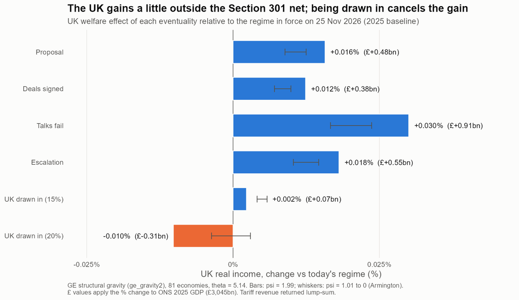

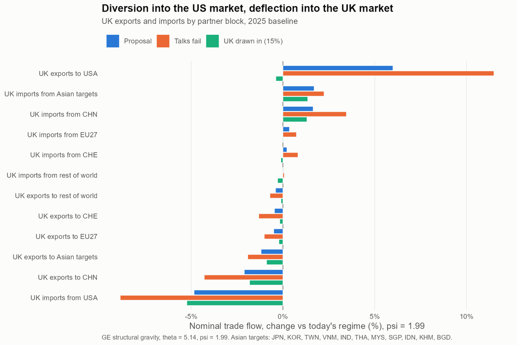

**How robust is the UK result?** At ψ = 1.99:

Table 6: UK welfare (%) and UK exports to the US (%) vs today’s regime, ψ = 1.99: baseline year × closure × weights

| Baseline | Closure | Weights | Welfare S1 | Welfare S3 | Welfare S5 | UK→US S1 | UK→US S3 | UK→US S5 |
| --- | --- | --- | --- | --- | --- | --- | --- | --- |
| 2022 | lumpsum | 2025 | 0.020 | 0.047 | 0.000 | 7.868 | 17.251 | 1.434 |
| 2022 | lumpsum | 2026H1 | 0.020 | 0.045 | 0.000 | 7.747 | 17.050 | 1.469 |
| 2022 | multiplicative | 2025 | 0.004 | 0.012 | -0.021 | 8.171 | 17.943 | 1.743 |
| 2022 | multiplicative | 2026H1 | 0.003 | 0.010 | -0.021 | 8.041 | 17.727 | 1.770 |
| 2022 | rev_eq | 2025 | 0.026 | 0.057 | 0.002 | 9.212 | 19.519 | 1.484 |
| 2022 | rev_eq | 2026H1 | 0.025 | 0.055 | 0.001 | 9.077 | 19.303 | 1.535 |
| 2025 | lumpsum | 2025 | 0.016 | 0.030 | 0.002 | 5.993 | 11.494 | -0.386 |
| 2025 | lumpsum | 2026H1 | 0.014 | 0.028 | 0.001 | 5.701 | 11.039 | -0.515 |
| 2025 | multiplicative | 2025 | 0.002 | 0.004 | -0.016 | 6.262 | 12.032 | -0.105 |
| 2025 | multiplicative | 2026H1 | 0.001 | 0.002 | -0.016 | 5.956 | 11.552 | -0.248 |
| 2025 | rev_eq | 2025 | 0.019 | 0.036 | 0.003 | 7.014 | 13.170 | -0.631 |
| 2025 | rev_eq | 2026H1 | 0.018 | 0.033 | 0.002 | 6.680 | 12.641 | -0.768 |

- **The direction and size of trade diversion are robust.** UK exports to the US rise by about 6–9% in S1 under every combination.
- **The welfare gain depends on the closure.**
  - Spending tariff revenue inside the equilibrium raises it slightly (0.019%).
  - Scaling trade deficits with output (multiplicative) cuts it to 0.002%. Under that closure, being drawn in at 15% already costs 0.016%.
- **Base year and weights matter less.** The 2022 baseline gives a somewhat larger gain (0.020%), because China’s share of US imports was twice as large. January–May 2026 weights give 0.014%.

## 4.3 Where the UK gains: product level

Table 7: UK exports to the US: products with the largest gains under S1 (PE, US$ m, 2025 values)

| HS6 | Product | UK exports 2025 | S1 | S1 % | S3 | S5 |
| --- | --- | --- | --- | --- | --- | --- |
| 382219 | Reagents; diagnostic or laboratory reagents on a backing, p… | 724.0 | 132.3 | 18.3 | 261.7 | -23.5 |
| 490199 | Printed matter; books, brochures, leaflets and similar prin… | 309.2 | 59.6 | 19.3 | 162.3 | -5.9 |
| 840890 | Engines; compression-ignition internal combustion piston en… | 833.3 | 57.1 | 6.9 | 129.8 | -21.3 |
| 848180 | Taps, cocks, valves and similar appliances; for pipes, boil… | 264.3 | 53.7 | 20.3 | 124.1 | -11.1 |
| 854370 | Electrical machines and apparatus; having individual functi… | 330.0 | 46.3 | 14.0 | 92.5 | -7.0 |
| 880730 | Aircraft and spacecraft; parts of aeroplanes, helicopters o… | 2124.2 | 43.5 | 2.0 | 97.0 | 0.0 |
| 392690 | Plastics; other articles n.e.c. in chapter 39 | 208.7 | 38.2 | 18.3 | 103.5 | -6.1 |
| 300490 | Medicaments; consisting of mixed or unmixed products n.e.c.… | 2791.6 | 36.6 | 1.3 | 86.6 | 36.6 |
| 330499 | Cosmetic and toilet preparations; n.e.c. in heading no. 330… | 232.1 | 32.2 | 13.9 | 93.3 | -20.6 |
| 902131 | Artificial parts of the body | 132.9 | 31.4 | 23.7 | 70.9 | 31.4 |
| 901320 | Lasers; other than laser diodes | 183.9 | 31.3 | 17.0 | 68.4 | -5.8 |
| 940320 | Furniture; metal, other than for office use | 189.5 | 28.0 | 14.8 | 72.1 | 23.0 |
| 901890 | Medical, surgical or dental instruments and appliances; n.e… | 291.4 | 26.9 | 9.2 | 55.9 | 12.3 |
| 852589 | Television cameras; n.e.c. in item no 8525.8 | 73.1 | 26.7 | 36.5 | 49.3 | 6.0 |
| 841191 | Turbines; parts of turbo-jets and turbo-propellers | 1218.8 | 26.6 | 2.2 | 56.4 | -0.6 |

The product layer agrees with the GE model: UK exports to the US rise by $3.4bn (6.2%) under S1. With an upper-tier elasticity of 1.5 the figure is $3.0bn, and under S3 it is $7.6bn.

The gains are spread across mid-tech manufacturing:

- diagnostic reagents;
- printed matter;
- diesel engines and valves;
- electrical apparatus;
- lasers and prosthetics;
- cosmetics.

The UK mainly displaces Chinese and Vietnamese suppliers.

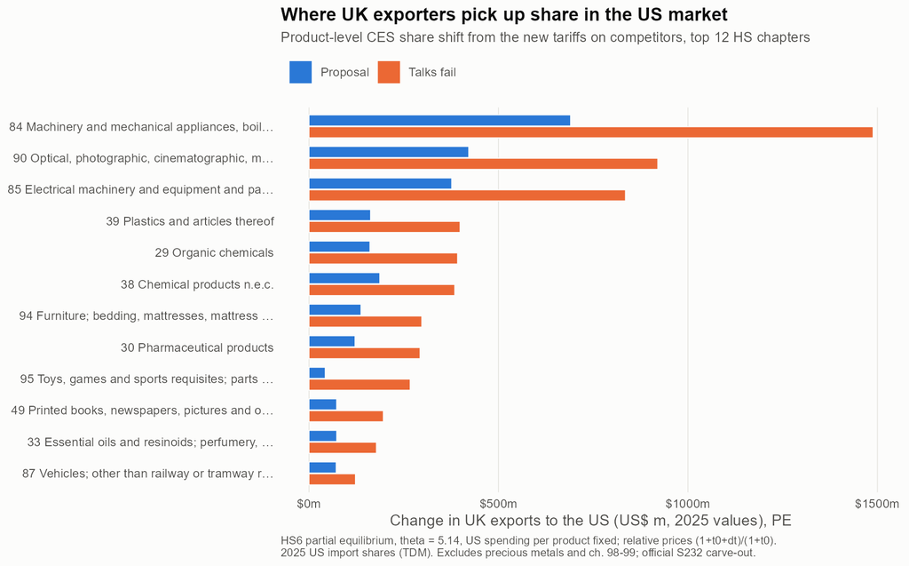

## 4.4 Trade deflection: the UK and the EU

Table 8: Highest deflection pressure on the UK, S3 (UK imports > $100m): redirected volume as % of UK imports of the product, and UK imports from the main source, Jan–May 2026 vs Jan–May 2025

[output not shown]

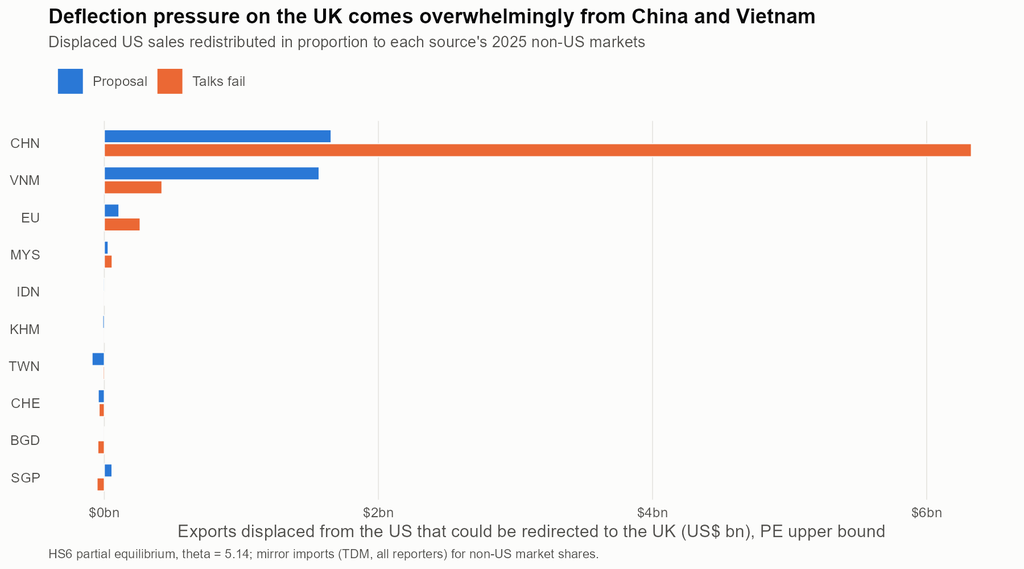

## 4.5 Uncertainty

Table 9: Monte Carlo (5,000 draws, 2025 baseline): UK welfare, % change vs today’s regime

| Scenario | Central | Median | 5% | 95% | P(gain) | Median £bn | 5% £bn | 95% £bn |
| --- | --- | --- | --- | --- | --- | --- | --- | --- |
| S1 Proposal | 0.016 | 0.010 | 0.007 | 0.014 | 1 | 0.301 | 0.206 | 0.413 |
| S2 Deals signed | 0.012 | 0.008 | 0.005 | 0.011 | 1 | 0.229 | 0.146 | 0.323 |
| S3 Talks fail | 0.030 | 0.021 | 0.016 | 0.026 | 1 | 0.632 | 0.489 | 0.797 |
| S4 Escalation | 0.018 | 0.012 | 0.009 | 0.016 | 1 | 0.369 | 0.272 | 0.493 |
| S5 UK drawn in 15% | 0.002 | 0.004 | 0.002 | 0.005 | 1 | 0.115 | 0.075 | 0.142 |
| S5b UK drawn in 20% | -0.010 | -0.004 | -0.008 | -0.002 | 0 | -0.134 | -0.247 | -0.057 |

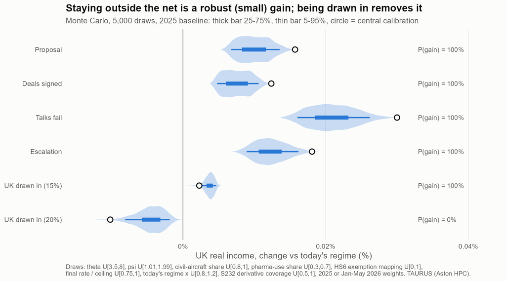

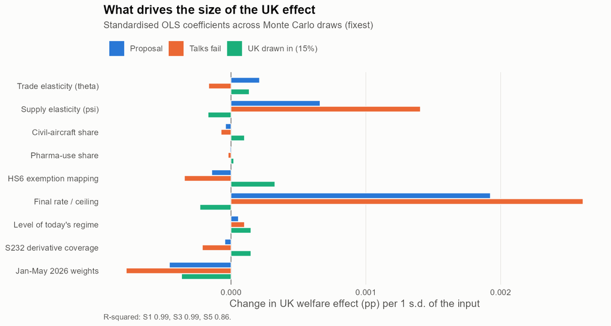

Every UK result has the same sign in all 5,000 draws:

- S1–S5 are positive;
- S5b is negative.

The weight year matters somewhat. The annex-mapping and Section 232 coverage assumptions matter little.

# 5 Discussion: what it means for the UK

1. **Staying outside the net is the main UK interest, but the stakes are modest.**
   - The proposal is worth about £0.3–0.5bn a year to the UK (median to central).
   - Being drawn in at 20% would turn that into a loss: £-0.13bn at the median.
   - The UK already pays the forced-labour 301 at its deal rate, and USTR has shown it can add economies.
   - Before the 5 January deadline, UK engagement should argue on the record that the UK does not fit the investigations’ profile, which is built on persistent surpluses and low capacity utilisation. The UK runs a large goods deficit and has a low manufacturing share.
2. **The gain is a preference margin, and margins erode.** Every competitor that lowers its rate through a deal (S2) or wins product exclusions takes some of it back. UK exporters of machinery, instruments and chemicals should prepare for the exclusion process.
3. **The UK–EU dimension.**
   - EU exporters lose about 1.6pp of US market access relative to the UK on average, and 5pp on covered goods, where they go from paying 2pp less than UK exporters to 3pp more. This trims UK exports to the EU slightly.
   - The EU faces several times the UK’s deflection pressure. That argues for UK–EU coordination on trade defence, especially for steel, aluminium and other safeguards.
4. **Deflection is a monitoring issue.** It amounts to under 1% of UK imports in aggregate, but up to 40% of imports in a few lines, some of which are already moving in the 2026 data. The Trade Remedies Authority’s tools and an early-warning watch-list (section 4.4) are the right response.
5. **The US loses in every scenario and draw.** The new tariffs mainly re-label duties that the Supreme Court struck down.

# 6 Caveats

# Revision note

This version replaces the first draft of the same day after a code and assumption review (`REVIEW_2026-11-25.md`). The main changes:

1. **“UK drawn in” corrected.** It is now the proposal *plus* the UK; the first draft used today’s regime plus the UK. A 20% variant was added.
2. **IEEPA reference rebuilt** as GTA rates on the last IEEPA day, like for like with today’s regime. The first draft used non-comparable statutory rates.
3. **Official sources** for the forced-labour tiers, the exemption annexes (verified line by line, including the UK’s country list) and the Section 232 product lists.
4. **2025 GE baseline.** China’s share of US imports is halved compared with 2022.
5. **Tariffs on US goods** by China, the EU and Canada added to all scenarios.
6. **Uncertainty:** today’s rates queried directly for 74 economies; Monte Carlo ranges re-centred, with Section 232 coverage and weight-year uncertainty added.
7. **Product layer:** today’s tariff levels; an upper-tier variant; EU deflection; a 2026 early check; precious metals excluded throughout.
8. **Closure sensitivity:** multiplicative closure and revenue spent in equilibrium.
9. **The rate table now shows average tariffs.** The earlier version showed a single covered good with a 2% MFN rate and left out China’s 2018 Section 301 duties, so it put China at 14.5%. The table now shows each economy’s trade-weighted average on all goods (GTA, cross-checked against the Yale Budget Lab tracker), and the covered-good example follows in the text.

**Effect on the headline numbers.** The UK proposal gain moved from +0.022% to 0.016% (central) and 0.010% (median). The “UK drawn in” result moved from −0.026% to 0.002% at 15% and -0.010% at 20% (central).

# Reproducibility

All code is in `2026 analysis/R/` and runs from that folder; see `README.md` for the run order. Trade data come from the local TDM and TRAINS databases on I:. The USTR FRNs, the forced-labour and Section 232 texts, the World Bank GDP series and the Comtrade descriptions were downloaded to `data/raw/`. GTA queries are stored in `data/raw/gta/`.